# PostEra ML Challenge

## Preliminary Notes

- This notebook contains a beginning problem (with 2 subtasks) and a medium problem.
- Please provide discussion of your assumptions, methods, and results for the medium problem!
- These exercises should not take an inordinate amount of time. These are meant to see how you think and that you meet a certain bar of qualification.
- You should need almost no Chemistry knowledge to complete this exercise. Perhaps one year of high school Chem is sufficient, if you don't know what an atom is, perhaps we are not the right company for you :)
- Please submit your code and answers in a report. This can be a pdf with code mixed in, or a nicely organized python notebook.

## As with many projects in python, installation is perhaps the most annoying part

For this project, we will be using [RDKit](https://www.rdkit.org/docs/GettingStartedInPython.html) which is unfortunately not pip-installable. However, it is installable through [Conda](https://docs.conda.io/en/latest/): see install instruction on RDKit's site [here](https://rdkit.org/docs/Install.html).

The [Getting Started with the RDKit in Python](https://www.rdkit.org/docs/GettingStartedInPython.html) document is a pretty good intro if you want to play around with it.

If you need an `environment.yml` file for installation with Anaconda, see [these instructions](https://docs.conda.io/projects/conda/en/latest/user-guide/tasks/manage-environments.html#creating-an-environment-from-an-environment-yml-file) and the file contents I provide below:

```
name: postera-interview-env
channels:
  - anaconda
  - conda-forge
  - defaults
dependencies:
  - numpy
  - scipy
  - pandas
  - matplotlib
  - rdkit
  - scikit-learn
```

If you really hate Conda, there are some DockerFiles available for lightweight builds from source, such as here: https://github.com/mcs07/docker-rdkit

### Background

I am not going to try to recreate here another intro to the basics of machine learning in Drug Discovery. For a quite good intro, see the intro to [this nice blog post](http://moreisdifferent.com/2017/9/21/DIY-Drug-Discovery-using-molecular-fingerprints-and-machine-learning-for-solubility-prediction/) or other resources on the web. However, I will mention some of the very, very basics.

This is a molecule:

[figure not shown]

How the heck do we represent this thing on paper without some pictures? How do we let machines learn about Asprin?

A couple of ways:

- Many of you probably look at the left image and see edges and nodes: a **graph**! This is correct, and if you would like a very nice overview on how early chemists were thinking about Graph Theory a long, long time ago, see [Chemoinformatics, an introduction for computer scientists](https://dl.acm.org/doi/10.1145/1459352.1459353). Also note that some of the first Graph Convolutional Neural Networks were used for molecular machine learning (https://arxiv.org/abs/1509.09292)
- Others might look at the image on the right, and notice the atoms have names. C is carbon, O is oxygen, ... Can we turn this into a **string** and use text-based learning. The answer is yes, please see the [Wikipedia page for SMILES strings](https://en.wikipedia.org/wiki/Simplified_molecular-input_line-entry_system) for more info.
- Often in ML, we want a fixed feature vector. Molecular fingerprinting allows us to turn a molecule into a **fixed-length feature vector**, and is classicly the most popular way of doing ML in Chemistry (at least pre 2015). See the [aforementioned blog post](http://moreisdifferent.com/2017/9/21/DIY-Drug-Discovery-using-molecular-fingerprints-and-machine-learning-for-solubility-prediction/) for info on fingerprinting.

# Beginning Problem

Many of you likely found us since we are running the [COVID Moonshot project](https://covid.postera.ai/covid), an international group of scientists working towards a COVID anti-viral. The project has generated a ton of data with Chemists around the world submitting designs of molecules that could be potential anti-viral compounds binding to the main protease of SARS-CoV-2.

Anyway, the data needs to be analyzed and prepared for analysis. So let's start with a very simple problem, essentially doing classical data analysis and classical medicinal chemistry (without fancy ML).

### First look at the DataFrame of Submissions

```python
import numpy as np
import pandas as pd
import matplotlib.pyplot as plt
%matplotlib inline
```

```python
from rdkit import Chem
from rdkit.Chem import Descriptors
from rdkit.Chem import AllChem
from rdkit.Chem.Draw import IPythonConsole # may be needed for viewing of molecules in notebook
```

```python
sub_df = pd.read_csv('https://covid.postera.ai/covid/submissions.csv')
sub_df = sub_df[['SMILES', 'CID', 'creator', 'rationale', 'MW']]
sub_df.head()
```

### Observing the columns

The two most important are `SMILES` which gives the identity of the molecule, and `MW`, which gives the molecular weight of the molecule. Molecular weight is a very simple, but important descriptor. Big molecules do not often make good drugs. Therefore, Chemists try to look for molecules with MW < 500 when they start to explore for drugs. In fact, many old-school chemists follow the [Rule of 5](https://en.wikipedia.org/wiki/Lipinski%27s_rule_of_five) when looking for drug-like compounds. Lipinski's rule states that, in general, an orally active drug has no more than one violation of the following criteria:

- No more than 5 hydrogen bond donors
- No more than 10 hydrogen bond acceptors
- A molecular mass less than 500 daltons
- An octanol-water partition coefficient (log P) that does not exceed 5

Note that all numbers are multiples of five, which is the origin of the rule's name.

#### Below I will show you how to calculate the mentioned descriptors on an example molecule from the dataframe

```python
sub_df.loc[4,'SMILES']
```

```python
Chem.MolFromSmiles('CS(=O)(=O)NCCc1c[nH]c2c(CCNS(C)(=O)=O)cccc12')
```

Note that you must run the descriptor object on the Mol object, constructed from the SMILES

```python
# MW
Descriptors.ExactMolWt(
    Chem.MolFromSmiles('CS(=O)(=O)NCCc1c[nH]c2c(CCNS(C)(=O)=O)cccc12')
)
```

```python
# cLogP (c stands for "calculated")
Descriptors.MolLogP(
    Chem.MolFromSmiles('CS(=O)(=O)NCCc1c[nH]c2c(CCNS(C)(=O)=O)cccc12')
)
```

```python
# HBD (Number of Hydrogen Bond Donors)
Descriptors.NumHDonors(
    Chem.MolFromSmiles('CS(=O)(=O)NCCc1c[nH]c2c(CCNS(C)(=O)=O)cccc12')
)
```

```python
# HBA (Number of Hydrogen Bond Acceptors)
Descriptors.NumHAcceptors(
    Chem.MolFromSmiles('CS(=O)(=O)NCCc1c[nH]c2c(CCNS(C)(=O)=O)cccc12')
)
```

### 1. The First "Beginning" Task

Please add the columns `cLogP`, `HBD`, `HBA` to the dataframe. Then please filter the dataframe down to only those molecules that have <= 1 Rule of 5 violations as defined earlier. Make a column called `ROF_violations` with this number (which should be 0 or 1 when you are done). Call this dataframe: `ROF_df`

#### Looking for similar molecules

Now that you have `ROF_df`, we may be interested in what molecules from this list of drug-like molecules are similar to inhibitors of the SARS 2003 Protein. The inhibitor of the original SARS protein I'm mentioning is below:

```python
SARS_mol = Chem.MolFromSmiles('O=C(c1cc(=O)[nH]c2ccccc12)N1CCN(c2ccccc2)CC1')
SARS_mol
```

Determining the similarity of two molecules is somewhat arbitrary, however it almost always involves fingerprints. Note that there are many different types of fingerprints, I am only using one.

```python
SARS_fp = np.array(AllChem.GetMorganFingerprintAsBitVect(SARS_mol,3,nBits=1024))
```

#### Now we need to get the fingerprint of another molecule and compare them to get a similarity value

```python
another_mol = Chem.MolFromSmiles('O=N(C1=CC=C(C2CCC(C(C3C4=C(C=CC=C4)NC(=O)C=3)=O)CC2)C=C1)=O')
```

```python
another_fp = np.array(AllChem.GetMorganFingerprintAsBitVect(another_mol, 3, nBits=1024))
```

There are many, many ways to compare these two vectors for how similar they are. Mean Squared difference, Tanimoto Similarity, Tversky Similarity, etc... I'm going to use the cosine similarity to estimate it for this one

```python
sim = np.sum(SARS_fp*another_fp) / np.sqrt( np.sum(SARS_fp)*np.sum(another_fp))
```

### 2. The Second "Beginning" Task

Find the 5 most similar molecules to `SARS_mol` in `ROF_df`. Do this by using at least 3 different similarity metrics described here: https://docs.eyesopen.com/toolkits/python/graphsimtk/measure.html

They may or may not be the same list of molecules. For each similarity metric, simply return the 5 molecules as a list of 5 SMILES strings.

#### If you are wondering how to visualize 5 random SMILES, the code below will work:

```python
random_smiles_list = list(sub_df['SMILES'])[:5]
Chem.Draw.MolsToGridImage(
    [Chem.MolFromSmiles(x) for x in random_smiles_list]
)
```

# Medium Problem

#### Please provide discussion of your assumptions, methods, and results for this problem!

You start writing an email. You are tired of coming up with original phrases, so you begin:

`I hope thi` *email finds you well*

And gmail has predicted the exact phrase you were going to write... Predictive text is everywhere these days in emails, texts, even emojis in instant messaging systems.

Currently, every chemist "types" molecules by using drawing software, then coverts it to SMILES. But what if we were to reverse this process and have people type in SMILES and predict the molecules they were thinking of. We could create predictive text for the chemical keyboard!

First, load the list of SMILES provided by PostEra or pull your favourite set from here: http://files.docking.org/catalogs/source/

We'd also reccomend filtering the SMILES to those with at most 50 characters:

```python
zinc_df = pd.read_csv('SMILES_Keyboard.csv')
zinc_df = zinc_df.loc[zinc_df['SMILES'].str.len()<50][['SMILES', 'NAME']].reset_index(drop=True)
zinc_df.head()
```

There is one issue that needs to be mentioned here: there are multiple ways to traverse a molecular graph; therefore, there are many valid SMILES strings for a given molecule. Thus RDKit implements what is called a `Canonical Smiles` which defines a canonical way of traversing the molecular graph, which guarentees a unique `Canonical Smiles` per molecule.

```python
# for example, this is a valid SMILES string
valid_smiles = 'OCCNC(c1c(n(c2c(cccc2)[n+]1=O)[O-])C)=O'
mol = Chem.MolFromSmiles(valid_smiles)
mol
```

```python
# we can get the canonical smiles like so
canonical_smiles = Chem.MolToSmiles(Chem.MolFromSmiles(valid_smiles))
canonical_smiles
```

```python
# and it encodes the same molecule
mol2 = Chem.MolFromSmiles(canonical_smiles)
mol2
```

The goal here is for a user to start typing, then you should predict the next letter of the SMILES string, just like you might predict the next word of text in a classical NLP task. This by itself is not too crazy. But what you should also do is predict the smallest possible molecule it could be.

Let's say that I have so far typed

`CC(`

Then the following SMILES are all valid:

- `CC(C)`
- `CC(O)`
- `CC(C)C`
- `CC(C)O`
- `CC(=O)`
- `CC(C)CC`

and could represent the molecule I was thinking of with reasonable probability. Essentially, what I want is a feature that looks for molecules that are "likely to be" the molecule I am hoping to eventually type and are closeby my currently typed string. Obviously, if the ultimate string I am thinking of is `CC(N)C(=O)COCN(C)(CNC)`, then that is impossible to predict from `CC(`. However, it is still helpful if at every step the nearby molecules are predicted. There are a couple of ways to do this, so try whatever seems promising.

#### In this task, here are a couple of things that may be helpful:

- You can check if a smiles string is valid or not if this function gives an error:

```python
invalid_smiles = 'C(((CC)C(D)))'
Chem.MolFromSmiles(invalid_smiles)
```

- For data augmentation purposes (if desired), you can get many valid SMILES strings for a given molecule with the doRandom option:

```python
Chem.MolToSmiles(mol, doRandom=True)
```

- Lastly, a perhaps useful tokenizer function is below to separate SMILES strings into separate tokens:

```python
def smi_tokenizer(smi):
    """
    Tokenize a SMILES molecule or reaction
    """
    import re
    pattern =  "(\[[^\]]+]|Br?|Cl?|N|O|S|P|F|I|b|c|n|o|s|p|\(|\)|\.|=|#|-|\+|\\\\|\/|:|~|@|\?|>|\*|\$|\%[0-9]{2}|[0-9])"
    regex = re.compile(pattern)
    tokens = [token for token in regex.findall(smi)]
    assert smi == ''.join(tokens)
    return ' '.join(tokens)
```

The defined tasks are as follows:

1. Create a model to predict the next letter in a given SMILES string given the previously typed letters. This is essentially the same as an NLP model that predicts the next word in a sentence.
2. Output the most likely molecules that are close to (extensions of) what I have typed. I am leaving this purposely ambiguous, since it can be implemented in many ways and there is not necessarily a "Correct" answer.
3. Please quanitfy the quality of your implentation with appropriate metrics for (1), such as accuracy of predicting the next character correctly. For (2) give some example outputs, such as I have below.

On (2), here is an example output from my own basic implementation.

I had typed `CCc1ccc`

My model gave these as likely molecules based on what I had typed:

```
SMI:  CCc1ccccc1
SMI:  CCc1ccccn1
SMI:  CCc1cccnc1
SMI:  CCc1ccccc1C
SMI:  CCc1ccccc1O
SMI:  CCc1ccccc1N
```

which correspond to the molecules below:

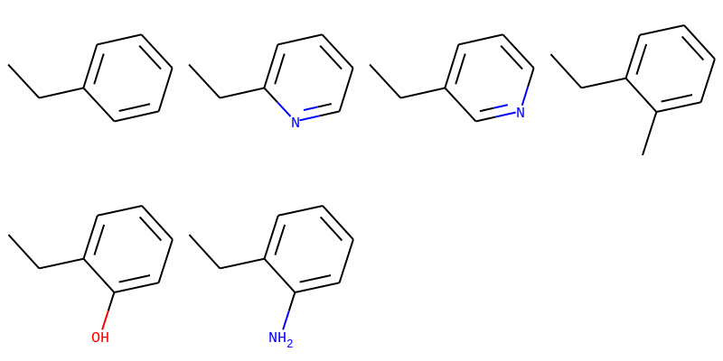